# Action Report: WeRateDogs Twitter data analysis

#### Yuseon Joung (08 December, 2020)

**WeRateDogs** is a popular Twitter account that give ratings to a dog picture. The account shares various dog pictures that catch your eyes, make you smile or sometimes even heart-warming.Here in this action report, I share the three insights, which are the results of analyzing 1964 tweets from the account. Moreover, each insight accompanies a brief explanation on which statistical methods were used.

## **Insight 1:**

we can expect the average ratings for the numerators for a new dog pictures on WeRateDogs to be in the range of **10.44 and 18.15 with 95% of confidence level.**

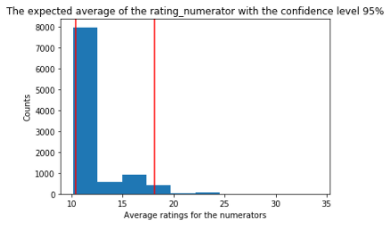

In order to get this insight, I stimulated a bootstrap sampling 10,000 times, with a sample size of 300.

## **Insight 2:**

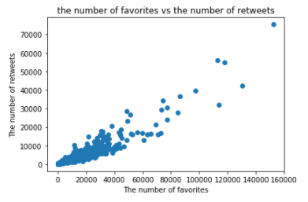

## **Insight 3:**

the dog breed with the biggest number of the average of the favorites is **Saluki**, followed by **french_bulldog, afghan_hound, giant_schnauzer, black-and-tan_coonhound, flat-coated_retriever, irish_water_spaniel, standard_poodle, english_springer and leonberg.**

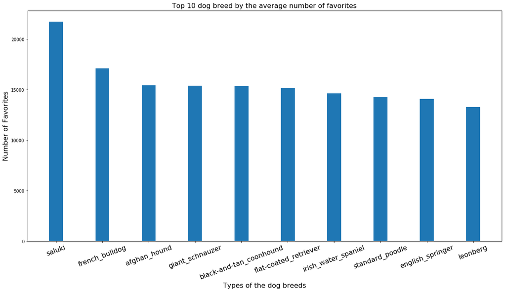

This is a result of a descriptive analysis. The average number of favorites for each dog breed was ranked and here are the top 10 results with the actual average number:

- 'saluki': 21753.0, 'french_bulldog': 17107.599999999999, 'afghan_hound': 15426.0, 'giant_schnauzer': 15399.0, 'black-and-tan_coonhound': 15329.5, 'flat-coated_retriever': 15162.625, 'irish_water_spaniel': 14642.666666666666, 'standard_poodle': 14238.714285714286, 'english_springer': 14076.333333333334, 'leonberg': 13281.0